Skip to main content

# Pilot report: LIONESS edges against the IFN score and its square

A review document: the pilot, its results, the draft spec, and the decisions log

Published

November 4, 2026

# Summary

**Scope.** This document reports the pilot[^1] for the proposal `proposal.md` (“When do LIONESS single-sample networks add information beyond the IFN score in SLE and RA?”): what the idea is, how the pilot was run, what it found, the full draft project spec, and the decisions made along the way. It was built from `project-spec.md`, `decisions.md`, the saved results in `pilot/results/`, and two small files of dataset facts in `pilot/` (`candidate_datasets.csv` and `gse45291_processing_dates.csv`, from GEO records opened on 2026-11-03), and every number in the text and figures is computed from those files when the document renders.

**Status.** In `STATUS.md` the pilot is marked `piloted-fail`[^2]. By the pre-registered rule the pilot failed: question 1 failed on size (the effect exists but is a fraction of the 0.05 required), question 2 failed, and clause 3(b) failed because the pre-registered matched quadratic model reached a quarter of the edges’ gain in the network cell. An exploratory probe run after the verdict (not part of the rule) found that the first-order edge features match the exact edges there, so the 3(b) shortfall lies in how the comparator was built, not in the closed form.

[output not shown]

**What needs your decision** (details in Action items and limitations): the status call; the open `[TO CONFIRM]` items in the spec (highlighted in yellow): the PRECISESADS access request and the milestone dates; and the two open items carried from the proposal (the data contingency, and the check of a supplement for the novelty claim).

# The idea

## In plain language

LIONESS[^3] gives every patient a value for every pair of genes, called an edge, meant to say how tightly the two genes move together in that patient. The closed form says what the value is made of. Take two genes that both rise with interferon activity, and a patient whose two genes sit 2 standard deviations above the average while the genes are correlated 0.5 across all patients. The edge is about $0.5 + 2 \times 2 - 0.25 \times (4 + 4) = 2.5$: mostly the product of the patient’s own two deviations. Nothing in it is specific to that patient’s gene coupling beyond those two numbers and the shared correlation.

The worry was that a patient with strong interferon activity gets large edges among all interferon genes, so edges would separate SLE from RA because of interferon alone, and a model with the interferon score would be credited with a network effect. The pilot measured how much edges add to the area under the ROC curve (AUC, the chance that a random SLE patient scores above a random RA patient) when the classes differ only in interferon activity. What is known: the closed form is exact, the extra AUC is small, and adding the squared interferon score to the reference model removes it. What is not known: how large these differences are in real blood, since no patient data were analyzed.

## Potential impact

LIONESS builds one network per sample from an aggregate network and has an R implementation (M. L. Kuijjer et al. 2019; Marieke L. Kuijjer et al. 2019). Earlier work showed that per-sample changes in correlation reduce to a product of standardized deviations for large reference sets (Yu et al. 2017), and documented that subpopulation size and differential expression shift LIONESS edges (Kuijjer et al. 2026). What is new here is the exact closed form of the LIONESS edge for Pearson and partial correlation, the formula behind the subpopulation effect, and a test of what edges add to a classifier.

The problem is how edge differences are read. Users compare edges between patient groups or feed them to classifiers, and read the result as rewired gene coupling. In diseases such as SLE, where one interferon program moves hundreds of genes, the closed form predicts that edges carry the square of the interferon level.

The pilot found that this artifact is real but modest. When the classes differed only in interferon activity, edges added 0.0067 to the AUC of a reference without the squared score in the moderate setting and 0.031 in the large one (Figure 4), and adding the squared score to the reference removed it in every such cell (Table 3). When the classes truly differed in co-expression, edges added 0.116 beyond the reference with the squared score, a real network signal. An exploratory probe after the verdict found that first-order edge features, which are computed from expression without building any network, gained 0.116 in the same setting, as much as the exact edges.

A user would do two things differently: put the squared interferon score, and any other shared factor’s square, in every reference model, and compare a network result with the first-order edge features, which can be computed for any study in seconds. If the equivalence holds in real data, published LIONESS results can be read as statements about quadratic expression features, and the cost of computing networks can be skipped. The application to PRECISESADS, once access is granted, is the analysis that will show whether the interferon artifact and the network signal are large in real blood.

## Application: the study behind the data

### The study

The proposed data come from PRECISESADS, a European study of systemic autoimmune diseases (Barturen et al. 2021), https://doi.org/10.1002/art.41610. It recruited a cross-sectional cohort of 955 patients with seven systemic autoimmune diseases, among them systemic lupus erythematosus (SLE) and rheumatoid arthritis (RA), and 267 healthy controls, from 18 centres, and measured the whole-blood transcriptome[^4], the DNA methylome, blood cell proportions by flow cytometry[^5], and the treatment each patient was taking. Its main finding was that patients cluster into four molecular groups that cut across diagnoses, one of them defined by an interferon (IFN)[^6] pattern shared by several diseases. The data are held by ELIXIR Luxembourg under controlled access (dataset ELU-2-E592B0-1, https://doi.org/10.17881/th9v-xt85) for non-commercial research on systemic autoimmune diseases (ELIXIR Luxembourg 2017). Access has not yet been requested, so no PRECISESADS data were opened for this pilot.

A search of the Gene Expression Omnibus[^7] for public series with both SLE and RA in blood found no usable alternative (Table 1). The largest, GSE45291, holds both diseases on one platform, but every processing date holds one disease only (Figure 2).

Table 1: Candidate datasets with SLE and RA from one study, from `candidate_datasets.csv` (GEO series and sample records and the PRECISESADS landing page, opened 2026-11-03). Empty cells: not stated in the record read.

| Dataset | Samples | SLE | RA | Controls | Usable | Reason |
| --- | --- | --- | --- | --- | --- | --- |
| PRECISESADS | whole blood RNA-seq | NA | NA | 267 | candidate | controlled access; counts by diagnosis in Supplementary Table 1 (not read) |
| GSE45291 | whole blood array | 292 | 493 | 20 | no | disease aliased with processing date; all RA treated |
| GSE17755 | peripheral blood cells array | 22 | 112 | 53 | no | 22 SLE |
| GSE235508 | whole blood RNA-seq (pregnancy) | 25 | 38 | 21 | no | too few patients; pregnancy population |
| GSE93272 | whole blood array | 0 | NA | NA | no | no SLE |
| GSE149050 | sorted immune cells RNA-seq | 203 | 0 | 85 | no | no RA |

### Why the AUC gain over the squared IFN score

The plain-language example says that a LIONESS edge between two IFN genes is mostly the square of how far a patient’s IFN activity sits from the average. The quantity that matters is therefore not whether edges separate SLE from RA, which they will whenever IFN does, but how much they add to a model that already holds the IFN score and its square: the gain in the area under the ROC curve[^8] (AUC) of the model with edges over the reference model, estimated out of sample. The proposed analysis compares 17 models in repeated nested cross-validation[^9], with two primary contrasts in fixed order: edges against the reference, and edges against the matched quadratic model.

### Did the original study compute it?

No. The PRECISESADS analysis clustered patients on transcriptome and methylome features and characterized the clusters; it built no single-sample networks, fitted no classifier of SLE against RA, and did not separate a network’s information from that of the IFN score. The question here is new for these data: whether per-patient networks carry diagnostic information beyond the IFN score, its square, and cell composition.

## In symbols

The sample’s standardized expression of gene $i$ ($z_{qi}$, its deviation from the reference mean in units of the reference standard deviation, divisor $N$) and the reference correlation of genes $i$ and $j$ ($r$) determine the LIONESS edge of sample $q$ ($e_q$), with $a = 1/(N-1)$:

$$\begin{aligned}
e_q &= N r - (N-1)\, \frac{r - a\, z_{qi} z_{qj}}{\sqrt{\left(1 - a\, z_{qi}^2\right)\left(1 - a\, z_{qj}^2\right)}} \\[8pt]
&= r + z_{qi} z_{qj} - \frac{r}{2}\left(z_{qi}^2 + z_{qj}^2\right) + O_p\!\left(N^{-1}\right).
\end{aligned}$$

If two genes load on a shared factor ($F$, the IFN activity) with loadings $a_i$ and $a_j$, then $z_{qi} z_{qj} \approx a_i a_j F_q^2$, and the edge carries $F_q^2$. Under a pure mean shift between classes, the class difference in mean edge is

$$\mathrm{E}_1[e] - \mathrm{E}_0[e] \approx (1 - 2\pi)\left[\Delta_i \Delta_j - \frac{r}{2}\left(\Delta_i^2 + \Delta_j^2\right)\right].$$

| Symbol | Meaning |
| --- | --- |
| $N$ | number of samples in the reference set |
| $z_{qi}$ | expression of gene $i$ in sample $q$, standardized by the reference (divisor $N$) |
| $r$ | Pearson correlation of genes $i$ and $j$ in the reference |
| $e_q$ | LIONESS edge of sample $q$ for the pair $(i, j)$ |
| $F_q$ | IFN activity of sample $q$ |
| $\pi$ | share of class 1 in the reference |
| $\Delta_i$ | class difference in mean expression of gene $i$, in pooled standard deviations |

What a user wants is the correlation of genes $i$ and $j$ among patients like $q$; what LIONESS computes is the reference correlation plus a quadratic function of $q$’s own expression. A classifier on edges is therefore, to first order, a classifier on the products $z_{qi} z_{qj}$ and squares $z_{qi}^2$, the same information a quadratic expression model uses.

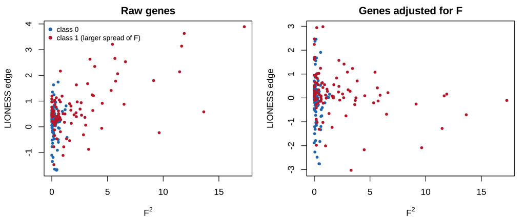

Figure 1: The idea, an illustration on made-up numbers (not pilot output): 200 simulated samples, two genes that each load 0.8 on a factor F, in two classes that differ only in the spread of F. Left: the LIONESS edge of each sample against its squared factor. Right: the same after both genes are adjusted for F.

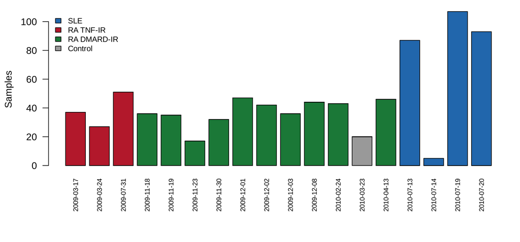

Figure 2: Real data: GSE45291, the largest public series with SLE and RA in whole blood. Each bar is one processing date (read from the date prefix of the sample titles) and its samples by group, from `gse45291_processing_dates.csv`. No date holds more than one group.

## Critiquing the model

Any model is a simplification, and the useful question is not whether it is true but where it bends and whether the bend matters for the question being asked. The model above was chosen so that the problem could be written as a formula and checked by simulation, and each simplification that made that possible is a place where real data may behave differently. The table lists the main ones. Work through it one row at a time. The first column names the feature and the symbols in the equations that carry it, so find them there first. Then decide in your own words how the feature could fail for real data before reading the second column, and finally read the third column for what should be done to check it. Several of these checks are natural first tasks for the project. Which of them the pilot examined, and which it left open, is for you to find when you read the Methods and Results that follow.

| Feature of the model | Why it may not be realistic | What should be done to check it |
| --- | --- | --- |
| Gaussian noise $\varepsilon$ and Gaussian $F$ | Expression on the log scale has heavier tails than normal, and the first-order form of $e_q$ is unbounded in $z$, so a few outlying samples can dominate the edges | Repeat the IFN-only cells with $t$-distributed noise and with real-data residuals resampled in place of $\varepsilon$ |
| One factor $F$ with equal loadings $a_g$ = 0.8 on 20 genes | Real IFN-stimulated genes respond with different strengths and to different IFN types, so $F$ is several correlated factors | Estimate the loadings and the number of IFN factors from PRECISESADS and simulate with them |
| The IFN score as the mean of five genes | The score measures $F$ with error, so $R_1$ cannot remove all of $F^2$; the size of the left-over depends on the score’s reliability | Vary the number of score genes and their loadings, and report the gain of edges over $R_1$ as a function of the score’s reliability |
| Composition $C$ as one factor, observed without error | Whole blood has several cell types whose shares are measured or estimated with error, and their squares enter the edges as $F^2$ does | Use the flow-cytometry proportions of PRECISESADS, with several cell types, and compare measured with estimated composition |
| Class differences confined to one mechanism per cell | SLE and RA differ in IFN, means, and co-expression at once | Simulate combined mechanisms at the sizes estimated from the data |
| The parameter values (shift, spread ratio, correlation change) | They are chosen to span small to large effects, not estimated from blood | Place PRECISESADS on each gradient: estimate the IFN difference between SLE and RA and the co-expression differences of the strongest modules |
| A fixed gene set of 45 genes, 990 edges | Studies select genes by variance or pathway, often after looking at the data, and use thousands of edges | Repeat with selection by variance inside each training fold and with larger gene sets |
| Independent samples, one per patient | Some cohorts have repeated samples or family structure | Use one sample per patient in the application |

# Methods

## Design

The pilot simulates two classes of 50 genes in 16 cells. Genes 1 to 20 load on an IFN factor $F$, genes 1 to 5 form the IFN score, genes 21 to 30 form a co-expressed module, and genes 31 to 50 load on a composition factor $C$. Each cell lets the classes differ in one way only: not at all (null), in the distribution of $F$ (IFN only), in the means of the module genes (mean shift), or in the module’s correlation (network). In each replicate, seven models are fitted in an outer 5-fold cross-validation, with every derived quantity (the IFN score and its residual, the standardization, the LIONESS reference) computed inside the training fold.

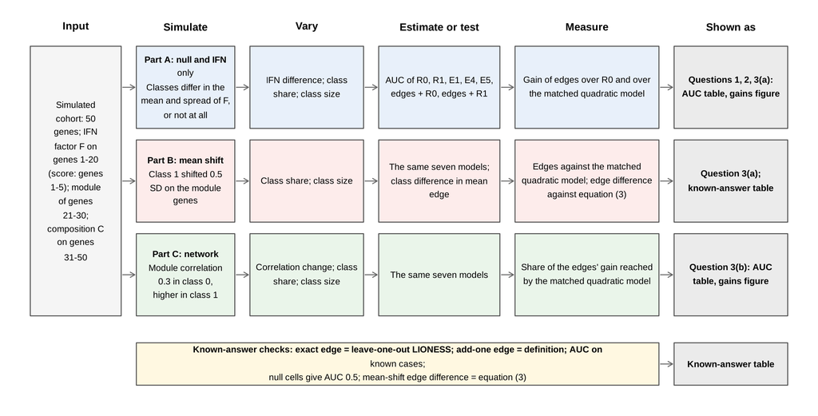

Figure 3: The design at a glance. Each row is one part of the pilot, read from left to right: what is simulated, which factors are varied, what is estimated, what is measured, and how the result is shown. The input is a simulated cohort of 50 genes with an IFN factor, a composition factor, and a co-expressed module. Every part feeds the AUC table (Table 3) and the figure of gains (Figure 4); the verdict is in Table 4, and the known-answer checks in Table 2.

Each figure and table in the Results traces back to one row of this diagram, and the row says what its points or entries represent.

| Part | What is simulated | Main factors | Replicates |
| --- | --- | --- | --- |
| A | Null (cells 1, 2) and IFN only (cells 3 to 7) | IFN difference (moderate, large), share 0.5 or 0.3, smaller class 40, 80, or 150 | 180 per cell |
| B | Mean shift of 0.5 SD on the module (cells 8 to 10) | share 0.5 or 0.3, smaller class 40 or 80 | 180 per cell |
| C | Module correlation change (cells 11 to 16) | change 0.1, 0.2, 0.4; share; class size | 180 per cell |

The seven models are: $R_0$, logistic regression on age, sex, composition, and the residual IFN score; $R_1$, $R_0$ plus the squared residual score and squared composition; E1, an elastic net[^10] on the 45 non-score genes; E4, regularized discriminant analysis[^11] on the genes, the residual score, and composition; E5, the matched quadratic model, an elastic net on the 990 pairwise products and 45 squares of the standardized genes; and the edge models, an elastic net on the 990 LIONESS edges of the same genes, with $R_0$ or with $R_1$. In every elastic net the reference covariates are unpenalized, so the added features must improve on them. The moderate IFN difference shifts the mean of $F$ by 0.5 standard deviations and multiplies its spread by 1.5 in class 1; the large one shifts it by 1 and multiplies the spread by 2.25.

## Known-answer checks

Known-answer checks come before any result, because every later number is only as good as the simulation that produced it. Each check sets up a case where the correct answer is known from theory, runs the simulation code on it, and compares the two. Agreement says nothing about the scientific question or about real data. It says that the code does what the model says. Disagreement means stopping to look for a bug before reading anything else, and the same checks apply to any code you write for the project.

Read each row of the table in four steps: the setting that was simulated, the known answer for that setting, what the simulation gave, and whether the gap between the two is small compared with the Monte Carlo standard error (MCSE). The MCSE is how much a simulated result moves from run to run because only a finite number of replicates was used. A gap within about two MCSE is noise, and a gap of several MCSE is a problem.

Table 2: Known-answer checks, from `results/known_answers.rds`.

| Check | Setting | Known answer | Simulation gave | How to read it |
| --- | --- | --- | --- | --- |
| Exact LIONESS Pearson edge equals leave-one-out LIONESS | N = 12, 6 genes, one outlier; largest absolute difference | 0.000 | 8.88e-15 | 8.882e-15 from the known value, against a tolerance of 1e-08, so the check passes. |
| Exact add-one edge equals (N + 1) r(+q) - N r | reference N = 12, 5 new samples; largest absolute difference | 0.000 | 5.33e-15 | 5.329e-15 from the known value, against a tolerance of 1e-08, so the check passes. |
| Exact LIONESS Pearson edge equals leave-one-out LIONESS | N = 60, 6 genes, one outlier; largest absolute difference | 0.000 | 1.42e-14 | 1.421e-14 from the known value, against a tolerance of 1e-08, so the check passes. |
| Exact add-one edge equals (N + 1) r(+q) - N r | reference N = 60, 5 new samples; largest absolute difference | 0.000 | 1.07e-14 | 1.066e-14 from the known value, against a tolerance of 1e-08, so the check passes. |
| First-order edge approaches the exact edge as N grows | N = 4000, r = 0.5; largest absolute difference | 0.000 | 0.0123 | 0.01235 from the known value, against a tolerance of 0.05, so the check passes. |
| AUC of perfectly separated scores | 5 against 5 | 1.000 | 1 | 0 from the known value, against a tolerance of 1e-08, so the check passes. |
| AUC of tied scores | all scores equal | 0.500 | 0.5 | 0 from the known value, against a tolerance of 1e-08, so the check passes. |
| Null cell: AUC of R0 is 0.5 | cell 1 (share 0.5, n 80), 180 replicates | 0.500 | 0.4953 (MCSE 0.0046) | 1.0 MCSE from the known value, so the gap is noise. |
| Null cell: AUC of R1 is 0.5 | cell 1 (share 0.5, n 80), 180 replicates | 0.500 | 0.4943 (MCSE 0.0047) | 1.2 MCSE from the known value, so the gap is noise. |
| Null cell: AUC of E1 is 0.5 | cell 1 (share 0.5, n 80), 180 replicates | 0.500 | 0.4960 (MCSE 0.0049) | 0.8 MCSE from the known value, so the gap is noise. |
| Null cell: AUC of E4 is 0.5 | cell 1 (share 0.5, n 80), 180 replicates | 0.500 | 0.5019 (MCSE 0.0043) | 0.4 MCSE from the known value, so the gap is noise. |
| Null cell: AUC of E5 is 0.5 | cell 1 (share 0.5, n 80), 180 replicates | 0.500 | 0.4924 (MCSE 0.0048) | 1.6 MCSE from the known value, so the gap is noise. |
| Null cell: AUC of N1R0 is 0.5 | cell 1 (share 0.5, n 80), 180 replicates | 0.500 | 0.4952 (MCSE 0.0046) | 1.0 MCSE from the known value, so the gap is noise. |
| Null cell: AUC of N1R1 is 0.5 | cell 1 (share 0.5, n 80), 180 replicates | 0.500 | 0.4932 (MCSE 0.0048) | 1.4 MCSE from the known value, so the gap is noise. |
| Null cell: AUC of R0 is 0.5 | cell 2 (share 0.3, n 80), 180 replicates | 0.500 | 0.4972 (MCSE 0.0039) | 0.7 MCSE from the known value, so the gap is noise. |
| Null cell: AUC of R1 is 0.5 | cell 2 (share 0.3, n 80), 180 replicates | 0.500 | 0.4992 (MCSE 0.0036) | 0.2 MCSE from the known value, so the gap is noise. |
| Null cell: AUC of E1 is 0.5 | cell 2 (share 0.3, n 80), 180 replicates | 0.500 | 0.4993 (MCSE 0.0035) | 0.2 MCSE from the known value, so the gap is noise. |
| Null cell: AUC of E4 is 0.5 | cell 2 (share 0.3, n 80), 180 replicates | 0.500 | 0.4985 (MCSE 0.0035) | 0.4 MCSE from the known value, so the gap is noise. |
| Null cell: AUC of E5 is 0.5 | cell 2 (share 0.3, n 80), 180 replicates | 0.500 | 0.5011 (MCSE 0.0038) | 0.3 MCSE from the known value, so the gap is noise. |
| Null cell: AUC of N1R0 is 0.5 | cell 2 (share 0.3, n 80), 180 replicates | 0.500 | 0.4986 (MCSE 0.0040) | 0.4 MCSE from the known value, so the gap is noise. |
| Null cell: AUC of N1R1 is 0.5 | cell 2 (share 0.3, n 80), 180 replicates | 0.500 | 0.5006 (MCSE 0.0037) | 0.2 MCSE from the known value, so the gap is noise. |
| Mean shift: class difference in mean edge minus equation (3) | cell 8 (share 0.5, n 80), module pairs, 180 replicates | 0.000 | -0.0016 (MCSE 0.0045) | 0.4 MCSE from the known value, so the gap is noise. |
| Mean shift: class difference in mean edge minus equation (3) | cell 9 (share 0.3, n 80), module pairs, 180 replicates | 0.000 | 0.0041 (MCSE 0.0036) | 1.1 MCSE from the known value, so the gap is noise. |
| Mean shift: class difference in mean edge minus equation (3) | cell 10 (share 0.3, n 40), module pairs, 180 replicates | 0.000 | 0.0053 (MCSE 0.0051) | 1.0 MCSE from the known value, so the gap is noise. |

0 of 17 rows with a standard error are more than 2 MCSE from the known value.

# Results

## How to read the outputs

Each output traces back to a row of the design diagram (the captions name the part where one applies). Read each in the same four steps. First, find its row in the diagram, which says what was simulated and what was varied. Second, work out what one point or one table entry is, usually one combination of the varied factors, averaged over replicates. Third, identify the reference value that would hold if nothing were wrong, shown as a dashed or grey line wherever possible. Fourth, look for where the results leave that reference, and for which settings they do. The outputs report three kinds of quantity.

- **Bias** is the average of an estimate minus its true value. When the truth is no difference, any average difference from 0 is a spurious difference created by the problem under study.
- **Level** is how often a test rejects when there is truly nothing to find. A correct test at 0.05 rejects 5% of the time, so a rate above 0.05 means too many false alarms.
- **Power** is how often a test rejects when there is a real effect. More is better, but only when the level is not inflated, because a test that rejects too often also looks powerful.

All rates and averages come from simulation, so each carries Monte Carlo error. That is why the figures show bars or a grey band, and why small differences should not be over-read.

This pilot reports AUC and paired AUC differences. A paired difference is computed within each replicate, between two models fitted to the same simulated cohort, and then averaged; its MCSE is the replicate standard deviation of the difference divided by the square root of the number of replicates. A difference of 0 means the added features carried no information.

## AUC gains by cell

**Figure guide (all parts).** Each row is one cell of the design, labelled by its mechanism, level, share of the smaller class ($\pi$), and size of the smaller class ($n$). The four colored points are four paired AUC differences averaged over 180 replicates: edges with $R_0$ against $R_0$, edges with $R_1$ against $R_1$, the matched quadratic model against $R_1$, and edges with $R_1$ against the matched quadratic model. The bars are two MCSE on each side, and the grey line is no difference. In the null cells every point should sit on the line. Look for: where the red points leave the line and the blue points do not; whether the purple points stay on the line in the IFN-only and mean-shift cells; how the green and blue points compare in the network cells.

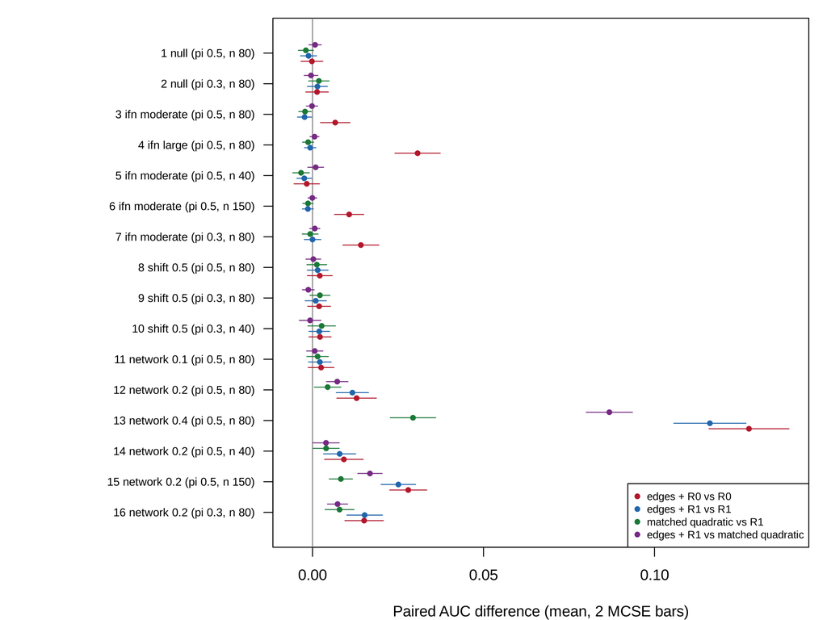

Figure 4: Pilot result (all parts): paired AUC differences by cell, means over replicates with bars of two MCSE, from `results/cell_summaries.rds`.

## Tables

**Table guide (all parts).** One row per cell; the columns are the mean out-of-fold AUC of each model over 180 replicates. The reference value is 0.5 in the null cells. Compare the edge models with $R_0$ and $R_1$ in the same row, and with E5. Which cells show a gap between edges with $R_0$ and edges with $R_1$, and is it the same size as the gap between $R_0$ and $R_1$?

Table 3: Mean out-of-fold AUC by cell and model, from `results/cell_summaries.rds`. The largest MCSE of any entry is given in the text below the table.

| Cell | R0 | R1 | E1 (genes) | E4 (RDA) | E5 (quadratic) | Edges + R0 | Edges + R1 |
| --- | --- | --- | --- | --- | --- | --- | --- |
| cell 1 (null, share 0.5, 80 per smaller class) | 0.495 | 0.494 | 0.496 | 0.502 | 0.492 | 0.495 | 0.493 |
| cell 2 (null, share 0.3, 80 per smaller class) | 0.497 | 0.499 | 0.499 | 0.498 | 0.501 | 0.499 | 0.501 |
| cell 3 (IFN only moderate, share 0.5, 80 in the smaller class) | 0.559 | 0.594 | 0.592 | 0.581 | 0.592 | 0.566 | 0.592 |
| cell 4 (IFN only large, share 0.5, 80 in the smaller class) | 0.626 | 0.710 | 0.710 | 0.704 | 0.709 | 0.657 | 0.710 |
| cell 5 (IFN only moderate, share 0.5, 40 in the smaller class) | 0.545 | 0.577 | 0.577 | 0.562 | 0.574 | 0.543 | 0.575 |
| cell 6 (IFN only moderate, share 0.5, 150 in the smaller class) | 0.577 | 0.613 | 0.612 | 0.605 | 0.612 | 0.587 | 0.612 |
| cell 7 (IFN only moderate, share 0.3, 80 in the smaller class) | 0.567 | 0.599 | 0.598 | 0.591 | 0.599 | 0.581 | 0.599 |
| cell 8 (mean shift 0.5, share 0.5, 80 in the smaller class) | 0.488 | 0.490 | 0.620 | 0.658 | 0.492 | 0.490 | 0.492 |
| cell 9 (mean shift 0.5, share 0.3, 80 in the smaller class) | 0.489 | 0.488 | 0.640 | 0.673 | 0.490 | 0.491 | 0.489 |
| cell 10 (mean shift 0.5, share 0.3, 40 in the smaller class) | 0.499 | 0.498 | 0.605 | 0.645 | 0.500 | 0.501 | 0.500 |
| cell 11 (network 0.1, share 0.5, 80 in the smaller class) | 0.483 | 0.481 | 0.480 | 0.504 | 0.483 | 0.486 | 0.483 |
| cell 12 (network 0.2, share 0.5, 80 in the smaller class) | 0.484 | 0.489 | 0.490 | 0.505 | 0.493 | 0.497 | 0.500 |
| cell 13 (network 0.4, share 0.5, 80 in the smaller class) | 0.498 | 0.501 | 0.499 | 0.555 | 0.531 | 0.625 | 0.617 |
| cell 14 (network 0.2, share 0.5, 40 in the smaller class) | 0.483 | 0.476 | 0.478 | 0.513 | 0.480 | 0.492 | 0.484 |
| cell 15 (network 0.2, share 0.5, 150 in the smaller class) | 0.492 | 0.492 | 0.494 | 0.512 | 0.501 | 0.520 | 0.517 |
| cell 16 (network 0.2, share 0.3, 80 in the smaller class) | 0.489 | 0.490 | 0.492 | 0.519 | 0.498 | 0.504 | 0.505 |

The largest MCSE of an AUC in the table is 0.0068.

**Table guide (the verdict).** One row per clause of the pre-registered rule: the quantity, its value with its MCSE, the threshold, and the outcome, read by `pilot/verdict.R`. Check that each outcome follows from its value and threshold, and that the combination gives the status.

Table 4: The pass rule applied clause by clause, from `results/verdict.rds`.

| Q | Clause | Cell | Quantity | Value | MCSE | Threshold | Outcome |
| --- | --- | --- | --- | --- | --- | --- | --- |
| 1 | (a) | cell 3 (IFN only moderate, share 0.5, 80 in the smaller class) | A(N1+R0) - A(R0) | 0.0067 | 0.0022 | >= 0.05 and > 3 MCSE | fail |
| 2 | (a) | cell 5 (IFN only moderate, share 0.5, 40 in the smaller class) | A(N1+R0) - A(R0) | -0.0017 | 0.0019 | >= 0.03 | fail |
| 3 | (a) | cell 3 (IFN only moderate, share 0.5, 80 in the smaller class) | A(N1+R1) - A(E5) | -0.0001 | 0.0008 | \|D\| <= max(0.01, 3 MCSE) = 0.0100 | pass |
| 3 | (a) | cell 4 (IFN only large, share 0.5, 80 in the smaller class) | A(N1+R1) - A(E5) | 0.0006 | 0.0007 | \|D\| <= max(0.01, 3 MCSE) = 0.0100 | pass |
| 3 | (a) | cell 5 (IFN only moderate, share 0.5, 40 in the smaller class) | A(N1+R1) - A(E5) | 0.0009 | 0.0012 | \|D\| <= max(0.01, 3 MCSE) = 0.0100 | pass |
| 3 | (a) | cell 6 (IFN only moderate, share 0.5, 150 in the smaller class) | A(N1+R1) - A(E5) | -0.0000 | 0.0006 | \|D\| <= max(0.01, 3 MCSE) = 0.0100 | pass |
| 3 | (a) | cell 7 (IFN only moderate, share 0.3, 80 in the smaller class) | A(N1+R1) - A(E5) | 0.0007 | 0.0007 | \|D\| <= max(0.01, 3 MCSE) = 0.0100 | pass |
| 3 | (a) | cell 8 (mean shift 0.5, share 0.5, 80 in the smaller class) | A(N1+R1) - A(E5) | 0.0003 | 0.0011 | \|D\| <= max(0.01, 3 MCSE) = 0.0100 | pass |
| 3 | (a) | cell 9 (mean shift 0.5, share 0.3, 80 in the smaller class) | A(N1+R1) - A(E5) | -0.0012 | 0.0009 | \|D\| <= max(0.01, 3 MCSE) = 0.0100 | pass |
| 3 | (a) | cell 10 (mean shift 0.5, share 0.3, 40 in the smaller class) | A(N1+R1) - A(E5) | -0.0007 | 0.0016 | \|D\| <= max(0.01, 3 MCSE) = 0.0100 | pass |
| 3 | (b) | cell 13 (network 0.4, share 0.5, 80 in the smaller class) | [A(E5) - A(R1)] - 0.9 [A(N1+R1) - A(R1)] | -0.0752 | 0.0030 | >= 0 | fail |

**Table guide (numbers quoted in the spec).** Each row recomputes a number that section 3 of the spec quotes, from the result files. Each should match the spec exactly.

Table 5: Numbers quoted in the spec’s section 3, recomputed from `results/cell_summaries.rds` and `results/verdict.rds`.

| Quantity | Value |
| --- | --- |
| Question 1: gain of edges + R0 over R0, cell 3 | 0.0067 (MCSE 0.0022) |
| Question 2: gain of edges + R0 over R0, cell 5 | -0.0017 (MCSE 0.0019) |
| Question 3(a): range of A(edges + R1) - A(E5) over cells 3 to 10 | -0.0012 to 0.0009 |
| Question 3(b): clause value, cell 13 | -0.0752 (MCSE 0.0030) |
| Status | piloted-fail |

# The draft spec

This is `project-spec.md`, read from the file when the document renders. Anything the agent[^12] left for the user to decide is highlighted in yellow and starts with “To confirm”.

| Proposal | `proposal.md`, final 2026-11-03 |
| --- | --- |
| Authors | as in `DESCRIPTION`, set by `tools/authors.R` before the final render |
| Written | 2026-11-03 |
| Status | final 2026-11-03; section 3 completed after the verdict, 2026-11-03 |

## 1. Question and why it matters

**Question (one sentence):** Is a LIONESS co-expression edge anything more than a closed-form quadratic function of each sample’s own expression, and, when classifying SLE against RA from whole blood, do LIONESS edges add information beyond the IFN score, its square, cell composition, and their own first-order (influence-function) features? (Revised 2026-11-03 after the first pilot, `proposal.md`, section 12.6; the question before it asked only about the IFN score and the matched quadratic model.)

**Why it matters:** A LIONESS edge is a known quadratic function of the sample’s own expression (proposal, section 4), so a network gain is a quadratic-expression gain unless it survives the matched comparison. In IFN-driven diseases, edges between IFN genes carry the square of the IFN factor, so a reference without that square credits IFN signal to the network. A user who reports network rewiring needs to know which comparisons the claim must survive.

## 2. Mechanism we suspect

The exact LIONESS Pearson edge is $e_q = N r - (N-1)(r - a z_{qi} z_{qj})/\sqrt{(1 - a z_{qi}^2)(1 - a z_{qj}^2)}$ with $a = 1/(N-1)$ (proposal, equation 1), which to first order is $r + z_{qi} z_{qj} - \tfrac{r}{2}(z_{qi}^2 + z_{qj}^2)$: the reference correlation plus the influence function of the correlation at the sample. Users read the edge as the correlation in the sample’s own subpopulation. Three gaps follow. Genes sharing a factor $F$ give edges near $a_i a_j F^2$, so edges add information over a reference with $F$ but not $F^2$ (zero when the classes have the same distribution of $F$, large when they differ in its spread). A mean shift between unbalanced classes moves the group mean of an edge by $(1 - 2\pi)[\Delta_i \Delta_j - \tfrac{r}{2}(\Delta_i^2 + \Delta_j^2)]$ with no change in co-expression (zero at $\pi = 0.5$). And any classification gain from edges should be matched by a linear model on the products $z_i z_j$ and squares $z_i^2$. If the mechanism is wrong, edges would add information beyond the matched quadratic model in cells with no co-expression difference.

## 3. Pilot

Filled twice: the plan now, the answers after the verdict (stage 2, step 5).

**Code:** `pilot/pilot.R`, run from the project root with `Rscript pilot/pilot.R`; functions in `R/`, tests in `tests/testthat/`; the verdict by `Rscript pilot/verdict.R`.

**Pass rule:** from the proposal, section 7, as numbers; clause by clause in `pilot/preregistration.md`, section 2.

1. In the IFN-only cell with the moderate IFN difference, $\pi$ = 0.5, and 80 per class, LIONESS edges added to $R_0$ raise the out-of-fold AUC by at least 0.05, and by more than three Monte Carlo standard errors.
2. The same gain is at least 0.03 at 40 per class.
3. 1. In every IFN-only and mean-shift cell, the AUC of edges with $R_1$ lies within 0.01 of the AUC of the matched quadratic model with $R_1$ (or within three Monte Carlo standard errors when that is wider); (b) in the network cell with change 0.4, $\pi$ = 0.5, and 80 per class, the matched quadratic model reaches at least 90% of the AUC gain of the edges over $R_1$.

Pass if 1, 2, and 3 pass; close call if 1 and 3 pass and the gain of question 2 lies between 0.01 and 0.03; fail if 1 or 3(a) fails.

**Verdict file:** `pilot/results/verdict.rds` (status `piloted-fail`), from `Rscript pilot/verdict.R`; 180 replicates per cell, 16 cells, 54 minutes on three cores.

**Plot:** `pilot/results/auc_gains.png`.

**The three pilot answers:**

## 4. ADEMP skeleton

**Aims.** (1) How much AUC do LIONESS edges add over a reference with the IFN score but not its square, when the classes differ only in the IFN factor? (2) Does the gain vanish against the matched quadratic model, in cells with and without a true co-expression difference? (3) How does the group mean of an edge depend on group balance under a pure mean shift?

**Data-generating mechanisms.**

- Factors varied: mechanism (null; IFN only; mean shift only; true network); IFN difference (moderate: mean of $F$ shifted 0.5 SD and SD ratio 1.5; large: shift 1 SD and ratio 2.25); conditional correlation change in a 10-gene module (0.1, 0.2, 0.4); share of the smaller class $\pi$ (0.5, 0.3); size of the smaller class (40, 80, 150).
- Factors fixed: 50 genes (genes 1 to 20 load 0.8 on $F$; genes 1 to 5 form the IFN score, as the five IFN5 genes do; genes 21 to 30 form a module with within-class noise correlation 0.3; genes 31 to 50 load 0.4 on composition $C$), so the IFN score and composition enter as they would in blood; Gaussian noise, so the known-answer cells have closed forms; age and sex unrelated to class, so the reference’s clinical terms are present but carry no signal; mean shift of 0.5 SD on the module genes in the mean-shift cells.
- Known-answer cells: the null cells (every AUC near 0.5); the closed forms of the edges (tests).

**Estimands.** The out-of-sample AUC of each model, and its difference from $R_1$ (or $R_0$): the probability that a random case from class 1 outranks a random case from class 0 under the model fitted on a sample of the cell’s size.

**Methods compared.** $R_0$ (logistic regression on age, sex, $C$, and the residual IFN score); $R_1$ ($R_0$ plus the squares of the residual score and $C$); E1 (elastic net on the 45 non-score genes with $R_1$ unpenalized); E4 (regularized discriminant analysis on the 45 genes, the residual score, and $C$); E5 (elastic net on the products and squares of the 45 standardized genes with $R_1$ unpenalized); N1 with $R_0$ and N1 with $R_1$ (elastic net on the 990 LIONESS-Pearson edges among the 45 genes, the reference unpenalized). Elastic net with $\alpha$ = 0.5 and $\lambda$ chosen by inner 5-fold cross-validation (glmnet 5.2); outer 5-fold cross-validation stratified by class. LIONESS edges for training samples use the training fold as reference (exact form); test samples are scored against the training fold (proposal, Result 5).

**Performance measures.** Out-of-fold AUC per model and replicate; paired differences from $R_0$ and $R_1$; Monte Carlo standard errors from the replicate standard deviation of the paired differences; in mean-shift cells, the observed group-mean edge difference against equation (3).

**Replicates and Monte Carlo SE target.** 200 per cell if the timing allows, giving a Monte Carlo standard error near 0.003 for an AUC difference with replicate standard deviation 0.04; the count is set from the timing run (pre-registration, section 3).

## 5. Application

**Dataset:** PRECISESADS, ELIXIR Luxembourg ELU-2-E592B0-1 (doi 10.17881/th9v-xt85), controlled access; not yet requested, so not on disk. **To confirm:** the access request is submitted by the user and Dr Grimes; the contingency if refused is open in proposal section 6

**Comparison:** untreated SLE against untreated RA, whole-blood RNA-seq, with flow-cytometry composition; counts by diagnosis to be read from the paper’s Supplementary Table 1 once accessed.

**What to show:** whether the AUC gain that edges show over a reference without the squared IFN score disappears against $R_1$ and against the matched quadratic model in real blood.

The pilot is a simulation only, as the proposal states (section 7).

## 6. Target journal

**Target journal:** BMC Bioinformatics

**Fallback:** Statistical Applications in Genetics and Molecular Biology

**The target’s word limit and AI policy:** structured abstract (Background, Results, Conclusions), 350 words; research article length not stated; AI use disclosed, AI not an author.

## 7. Milestones

| Stage | Ends with | Due |
| --- | --- | --- |
| 2. Pilot | `pilot/pilot-report.html`, the verdict file, `pilot/decisions.md` | 2026-11-04 |
| 3. Manuscript, design stop | `protocol.md` from the approved design | **To confirm:** date |
| 3. Manuscript, first draft | `manuscript/manuscript.html` in draft mode | **To confirm:** date |
| 3. Manuscript, settled | the draft after the revision rounds | **To confirm:** date |
| 4. Background report | `background/background.html` | **To confirm:** date |
| 5. Mock review | the last `review/round-N/` | **To confirm:** date |
| Submission | the final render and the checker in final mode | **To confirm:** date |

## 8. Out of scope

The project must not add:

- Single-sample methods beyond the six in the model list (CSN, SSPGI, LIONESS on mutual information): each is its own critique.
- A new single-sample network method, or a corrected LIONESS: a constructive paper for later.
- Diseases beyond SLE and RA, although PRECISESADS holds seven: a second application is a different paper.
- A biomarker or a diagnostic classifier for clinical use: the classification task is the instrument of the critique, not the result.
- Second-order theory beyond the exact forms (bounds for heavy tails, regularized partial correlation): parked as its own theory note.

## 9. Reading

1. 1. After reading, a reader can answer: what are the aggregate and the background network, and how is the sample’s edge obtained from them?
2. 2. After reading, a reader can answer: under what condition does the per-sample change in Pearson correlation reduce to the product of standardized deviations, and what does that reduction drop?
3. 3. After reading, a reader can answer: which edge type gets higher weights in the smaller subpopulation, and for which methods?

# Decisions log

This is the agent’s `decisions.md`, read from the file when the document renders.

## D0. Literature pass

The literature behind the pilot is the proposal’s section 5, read in full text at the reference check of stage 1 (`log/01-idea-review.md`, D18 and D19): the product-of-deviations form is published for per-sample changes in correlation (Yu et al. 2017), and the effect of differential expression and subpopulation size on LIONESS edges is documented empirically (Kuijjer, De Marzio, and Glass 2026). Nothing was read for the pilot beyond that.

## D2. R version

**What.** R 4.6.2, not the 4.5.2 recorded in the template’s `renv.lock`; the lockfile was updated by `renv::snapshot()`. **Alternatives.** Ubuntu’s R 4.3.3, older than the lockfile. **Why.** The CRAN repository for Ubuntu 24.04 serves the current release only; every locked package installed as a binary. **Check.** Nothing; the lockfile records the version.

## D3. Dependencies

**What.** glmnet 5.2 added for the elastic nets; regularized discriminant analysis written in base R (`RdaScore()`, `FitRda()`). **Alternatives.** The klaR package for regularized discriminant analysis. **Why.** One dependency earns its place (the elastic net on 1,035 features); the discriminant analysis is 40 lines with a test. **Check.** That the shrinkage form (toward the pooled covariance, then toward the mean diagonal) is the one the paper should describe.

## D4. Gene set fixed in the pilot

**What.** The gene set is genes 6 to 50 in every fold, not the 50 most variable genes chosen in each training fold as the proposal’s full design states. **Alternatives.** Variance screening inside each fold. **Why.** In the simulation every non-score gene is relevant by construction, and fixing the set keeps the matched quadratic model and the edges on the same genes; screening is a design choice for the real data. **Check.** Whether stage 3 should test screening in the simulation too (the critique table of the report lists it).

## D5. One outer cross-validation per replicate

**What.** One outer 5-fold split per replicate, not the 20 repeats of the full design. **Why.** Repeats average over splits of one fixed dataset; in a simulation the replicates already average over datasets and splits. **Check.** Nothing.

## D6. Reference for training and test edges

**What.** Training samples’ edges use the training fold as reference (leave-one-out, $N_{\text{train}}$ samples); test samples’ edges add the sample to the training fold ($N_{\text{train}} + 1$). **Alternatives.** Building every edge from the whole cohort, which lets the test fold shape the reference. **Why.** The reference must never hold a test sample (proposal, Result 5); the scale of the two forms differs by one sample in $N$. **Check.** That the small difference between leave-one-out and add-one scaling does not matter (it is of order $1/N$).

## D7. Replicates

**What.** 180 replicates per cell, from the timing run (`pilot/results/timing.rds`), entered in the pre-registration’s section 6 and committed before the run. **Why.** 200 replicates projected just over the one-hour box.

## D8. No data description

**What.** No `pilot/describe_data.R`: no data set was downloaded. **Why.** PRECISESADS is under controlled access and not yet requested; the GEO candidates were ruled out at stage 1 from their records. The report’s application section uses two small files of facts from the records opened (`candidate_datasets.csv`, `gse45291_processing_dates.csv`), whose processing dates are read from the date prefix of the GEO sample titles, an interpretation of the titles. **Check.** The access request.

## D9. Exploratory probe of clause 3(b), after the verdict

**What.** Not pre-registered, run after the verdict to explain the failure of clause 3(b): 60 new replicates of cell 13 (seeds offset by 100000), comparing the edges with $R_1$, the pre-registered matched quadratic model, and the first-order edges $r + z_i z_j - \tfrac{r}{2}(z_i^2 + z_j^2)$ as features with $R_1$ (`pilot/posthoc/probe_cell13.R`, `pilot/results/posthoc_cell13.rds`). **Finding.** The first-order edges gained as much as the exact edges over $R_1$ (their difference was -0.005, MCSE 0.002), while the pre-registered quadratic model gained a quarter as much. The first-order edges are a linear combination of the same products and squares, so the information is the same; the elastic-net penalty treats the two parametrizations differently, because the edge form puts each pair’s co-expression into one feature while the product-and-square form spreads it over a product and two squares shared with other pairs. **Why it matters.** The matched comparator of the proposal should be the first-order edge features, not products and squares as separate features. With it, edges added nothing beyond their first-order form in the one cell probed. **Check.** This is one cell and 60 replicates, outside the pre-registration; it is evidence for the revision, not a pilot result.

## What was not done

- No real data were analyzed.
- Eleven of the 17 models were not run in the pilot (it ran $R_0$, $R_1$, E1, E4, E5, and N1, the last with $R_0$ and with $R_1$): the clinical baselines B1 and B2, the random forest (E2), shrinkage linear discriminant analysis (E3), the partial-correlation edges (N2), SSN (N3), iENA (N4), SWEET (N5), BONOBO (N6), the module eigengenes (N7), and the differential-correlation pairs (N8).
- No heavy-tailed noise, no combined mechanisms, no variance screening of genes, no measurement error in composition.

# Action items and limitations

## Action items

1. **Decide the status.** The rule gives `piloted-fail`. The options are a revised proposal and a re-pilot (`pilot-b/`) with the first-order edge features as the matched comparator and a question 1 sized to the effects seen, a re-scope around the equivalence result, or dropping or parking the idea.
2. **Resolve the yellow `[TO CONFIRM]` items** in the spec: the PRECISESADS access request and the milestone dates.
3. **Verify the citations.** Every citation was checked against its Crossref or PubMed record and read in full text at stage 1, except Devlin et al. (1975) and Croux and Dehon (2010), whose full texts are pending.
4. **Read the exploratory probe as evidence for the revision, not as a result.** It is one cell and 60 replicates outside the pre-registration.

## Limitations

- Everything here is simulation under Gaussian noise, one interferon factor with equal loadings, and one composition factor; no patient data were analyzed.
- Six of the 17 models were run; SSN, iENA, SWEET, BONOBO, the module eigengenes, the differential-correlation pairs, and the partial-correlation edges were not.
- The IFN score was the mean of five genes measured with noise; how much of the squared factor the reference removes depends on that reliability, which was not varied.
- The equivalence of first-order and exact edges as classifier features was seen in one cell, after the verdict.

## References

Barturen, G., S. Babaei, F. Català-Moll, et al. 2021. “Integrative Analysis Reveals a Molecular Stratification of Systemic Autoimmune Diseases.” *Arthritis & Rheumatology* 73 (6): 1073-85. https://doi.org/10.1002/art.41610.

Croux, Christophe, and Catherine Dehon. 2010. “Influence Functions of the Spearman and Kendall Correlation Measures.” *Statistical Methods & Applications* 19 (4): 497-515. https://doi.org/10.1007/s10260-010-0142-z.

Devlin, Susan J., R. Gnanadesikan, and J. R. Kettenring. 1975. “Robust Estimation and Outlier Detection with Correlation Coefficients.” *Biometrika* 62 (3): 531-45. https://doi.org/10.1093/biomet/62.3.531.

ELIXIR Luxembourg. 2017. *PRECISESADS: Cross Sectional Study & Inception Cohort Data (V1.0)*. https://doi.org/10.17881/th9v-xt85.

Kuijjer, M. L., M. G. Tung, G. Yuan, J. Quackenbush, and K. Glass. 2019. “Estimating Sample-Specific Regulatory Networks.” *iScience* 14: 226-40. https://doi.org/10.1016/j.isci.2019.03.021.

Kuijjer, Marieke L., Ping-Han Hsieh, John Quackenbush, and Kimberly Glass. 2019. “lionessR: Single Sample Network Inference in R.” *BMC Cancer* 19 (1): 1003. https://doi.org/10.1186/s12885-019-6235-7.

Kuijjer, Marieke, Margherita De Marzio, and Kimberly Glass. 2026. *Challenges and Opportunities in Single-Sample Network Modeling*. https://doi.org/10.64898/2026.02.27.708608.

Yu, Xiangtian, Jingsong Zhang, Shaoyan Sun, Xin Zhou, Tao Zeng, and Luonan Chen. 2017. “Individual-Specific Edge-Network Analysis for Disease Prediction.” *Nucleic Acids Research* 45 (20): e170. https://doi.org/10.1093/nar/gkx787.

## Footnotes

[^1]: A pilot is a quick, small first run of the proposal’s simulation, done before the project goes further, to check that the idea is worth the time. It asks three questions: does the effect exist, is it large enough at realistic sample sizes, and is there an obvious fix or diagnostic? The proposal (`proposal.md`) holds the pilot plan and its pass criteria.
[^2]: `piloted-pass` means all three pilot questions got a clear yes. `piloted-fail` means at least one clearly did not, so the project should not go on as proposed. `piloted-close-call` means at least one answer could be read either way, so the call is stated both ways: the reading that passes and the reading that fails.
[^3]: LIONESS (Linear Interpolation to Obtain Network Estimates for Single Samples) builds a network from all samples and again without one sample, and scales the difference to give that sample’s network.
[^4]: The transcriptome is the set of RNA molecules in a sample; here, the expression level of each gene in whole blood, measured by RNA sequencing.
[^5]: Flow cytometry counts cells by their surface markers, which gives the proportions of B cells, T cells, monocytes, and neutrophils in a blood sample.
[^6]: Type I interferons are signaling proteins of the immune response; many SLE patients, and some RA patients, have high blood expression of the genes they induce (the IFN signature), summarized by an IFN score.
[^7]: The Gene Expression Omnibus is the public archive of gene expression data run by the US National Center for Biotechnology Information.
[^8]: The area under the ROC curve is the probability that a randomly chosen SLE patient gets a higher score than a randomly chosen RA patient; 0.5 is chance and 1 is perfect separation.
[^9]: In cross-validation the data are split into folds, each model is fitted without one fold and scored on it, and the scores are pooled; nested cross-validation tunes the model inside each training part, so that the held-out fold is never used for any choice.
[^10]: The elastic net is logistic regression with a penalty that shrinks coefficients and sets many to zero, so it can use more features than samples; glmnet is the R package that fits it.
[^11]: Regularized discriminant analysis classifies with a separate covariance matrix per class, shrunk toward a pooled one and toward a diagonal, which gives a quadratic decision rule (quadratic discriminant analysis) when the shrinkage is small.
[^12]: The AI agent that ran the pilot, wrote the files this document is built from, and kept a log of its decisions.